# 沪深300

数据为2024年10月11的收盘数据

## 获得指数实时行情

|  | 代码 | 名称 | 成交额 |
| --- | --- | --- | --- |
| 69 | 000902 | 中证流通 | 9.514478e+11 |
| 67 | 000985 | 中证全指 | 9.433948e+11 |
| 95 | 000906 | 中证800 | 4.862159e+11 |
| 79 | 000001 | 上证指数 | 4.167595e+11 |
| 76 | 000002 | Ａ股指数 | 4.162487e+11 |
| 78 | 000017 | 新综指 | 4.128445e+11 |
| 83 | 000090 | 上证流通 | 4.128445e+11 |
| 20 | 000967 | 基本600 | 3.711798e+11 |
| 99 | 000300 | 沪深300 | 3.221819e+11 |
| 123 | 000984 | 300等权 | 3.221819e+11 |
| 109 | 000907 | 中证700 | 3.052685e+11 |
| 89 | 000047 | 上证全指 | 2.835888e+11 |
| 16 | 000100 | 上证F500 | 2.469100e+11 |
| 113 | 000004 | 工业指数 | 2.397246e+11 |
| 39 | 000060 | 全R价值 | 2.264916e+11 |
| 13 | 000965 | 基本200 | 2.236349e+11 |
| 85 | 000046 | 上证中小 | 1.977835e+11 |
| 19 | 000053 | 180基本 | 1.937797e+11 |
| 84 | 000010 | 上证180 | 1.937797e+11 |
| 117 | 000051 | 180等权 | 1.937797e+11 |

本来应该找全收益指数的，但试了几个地方都没有这个数据。全收益包括了分红进行再投资，所以收益率会比价格指数高。

## 获得指数成分

| 纳入日期 | 品种代码 | 品种名称 | 纳入日期 |
| --- | --- | --- | --- |
| 2005 | 34 | 34 | 34 |
| 2006 | 4 | 4 | 4 |
| 2007 | 13 | 13 | 13 |
| 2008 | 9 | 9 | 9 |
| 2009 | 5 | 5 | 5 |
| 2010 | 9 | 9 | 9 |
| 2011 | 9 | 9 | 9 |
| 2012 | 7 | 7 | 7 |
| 2013 | 9 | 9 | 9 |
| 2014 | 5 | 5 | 5 |
| 2015 | 10 | 10 | 10 |
| 2016 | 6 | 6 | 6 |
| 2017 | 16 | 16 | 16 |
| 2018 | 26 | 26 | 26 |
| 2019 | 16 | 16 | 16 |
| 2020 | 25 | 25 | 25 |
| 2021 | 33 | 33 | 33 |
| 2022 | 30 | 30 | 30 |
| 2023 | 22 | 22 | 22 |
| 2024 | 12 | 12 | 12 |

- 这个数据有20个重复的项目。但只有它有纳入时间的选项。
- 2005年最开始纳入指数的300家，现在只剩下了34家了。
- 2018年以来，更换成分的速度明显加快。

## 获得指数历史行情

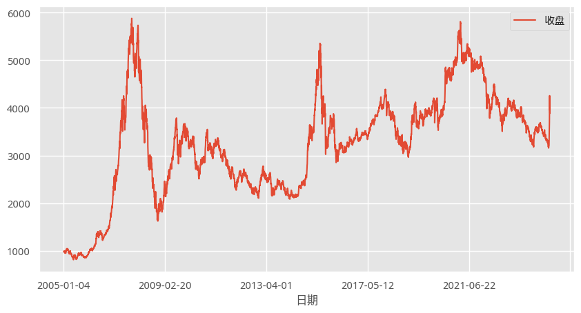

## 获取成分股历史行情

## 交易天数

| years | 1 | 2 | 3 | 4 | 5 | 6 | 7 | 8 | 9 | 10 | 11 | 12 | 13 | 14 | 15 | 16 | 17 | 18 | 19 |
| --- | --- | --- | --- | --- | --- | --- | --- | --- | --- | --- | --- | --- | --- | --- | --- | --- | --- | --- | --- |
| count | 2 | 10 | 11 | 16 | 13 | 12 | 13 | 3 | 18 | 6 | 2 | 17 | 15 | 17 | 7 | 19 | 12 | 2 | 105 |

## 总增长

近20年的总增长情况

```
'总体正增长:266家'
```

|  | count | mean | std | min | 25% | 50% | 75% | max |
| --- | --- | --- | --- | --- | --- | --- | --- | --- |
| 0 | 300.0 | 1.586861 | 1.339897 | -1.217562 | 0.487904 | 1.443721 | 2.609983 | 5.819524 |

|  | -2 | -1 | 0 | 1 | 2 | 3 | 4 | 5 |
| --- | --- | --- | --- | --- | --- | --- | --- | --- |
| 0 | 2 | 32 | 83 | 69 | 66 | 37 | 9 | 2 |

- 大部分公司的增长在2倍以内。
- 超过2倍的数量为114家。换算下来大约每年10%

```
'from 5.82 to -1.22'
```

|  | 0 | 1 | 2 | 3 | 4 | 5 | 6 | 7 |
| --- | --- | --- | --- | --- | --- | --- | --- | --- |
| 0 | [藏格矿业](https://data.eastmoney.com/stockdata/000408.html) | [贵州茅台](https://data.eastmoney.com/stockdata/600519.html) | [格力电器](https://data.eastmoney.com/stockdata/000651.html) | [山西汾酒](https://data.eastmoney.com/stockdata/600809.html) | [恒瑞医药](https://data.eastmoney.com/stockdata/600276.html) | [泸州老窖](https://data.eastmoney.com/stockdata/000568.html) | [片仔癀](https://data.eastmoney.com/stockdata/600436.html) | [长春高新](https://data.eastmoney.com/stockdata/000661.html) |
| 1 | [中航沈飞](https://data.eastmoney.com/stockdata/600760.html) | [恒生电子](https://data.eastmoney.com/stockdata/600570.html) | [古井贡酒](https://data.eastmoney.com/stockdata/000596.html) | [闻泰科技](https://data.eastmoney.com/stockdata/600745.html) | [三一重工](https://data.eastmoney.com/stockdata/600031.html) | [伊利股份](https://data.eastmoney.com/stockdata/600887.html) | [五 粮 液](https://data.eastmoney.com/stockdata/000858.html) | [中际旭创](https://data.eastmoney.com/stockdata/300308.html) |
| 2 | [新和成](https://data.eastmoney.com/stockdata/002001.html) | [华东医药](https://data.eastmoney.com/stockdata/000963.html) | [北方稀土](https://data.eastmoney.com/stockdata/600111.html) | [上海医药](https://data.eastmoney.com/stockdata/601607.html) | [北新建材](https://data.eastmoney.com/stockdata/000786.html) | [国电南瑞](https://data.eastmoney.com/stockdata/600406.html) | [海尔智家](https://data.eastmoney.com/stockdata/600690.html) | [紫光国微](https://data.eastmoney.com/stockdata/002049.html) |
| 3 | [山东黄金](https://data.eastmoney.com/stockdata/600547.html) | [万华化学](https://data.eastmoney.com/stockdata/600309.html) | [立讯精密](https://data.eastmoney.com/stockdata/002475.html) | [云南白药](https://data.eastmoney.com/stockdata/000538.html) | [中航西飞](https://data.eastmoney.com/stockdata/000768.html) | [航发动力](https://data.eastmoney.com/stockdata/600893.html) | [北方华创](https://data.eastmoney.com/stockdata/002371.html) | [华兰生物](https://data.eastmoney.com/stockdata/002007.html) |
| 4 | [东方财富](https://data.eastmoney.com/stockdata/300059.html) | [通威股份](https://data.eastmoney.com/stockdata/600438.html) | [中科曙光](https://data.eastmoney.com/stockdata/603019.html) | [川投能源](https://data.eastmoney.com/stockdata/600674.html) | [阳光电源](https://data.eastmoney.com/stockdata/300274.html) | [三花智控](https://data.eastmoney.com/stockdata/002050.html) | [特变电工](https://data.eastmoney.com/stockdata/600089.html) | [东方雨虹](https://data.eastmoney.com/stockdata/002271.html) |
| 5 | [浪潮信息](https://data.eastmoney.com/stockdata/000977.html) | [中国巨石](https://data.eastmoney.com/stockdata/600176.html) | [恒力石化](https://data.eastmoney.com/stockdata/600346.html) | [宝信软件](https://data.eastmoney.com/stockdata/600845.html) | [牧原股份](https://data.eastmoney.com/stockdata/002714.html) | [同花顺](https://data.eastmoney.com/stockdata/300033.html) | [四川路桥](https://data.eastmoney.com/stockdata/600039.html) | [福耀玻璃](https://data.eastmoney.com/stockdata/600660.html) |
| 6 | [招商银行](https://data.eastmoney.com/stockdata/600036.html) | [中金黄金](https://data.eastmoney.com/stockdata/600489.html) | [科大讯飞](https://data.eastmoney.com/stockdata/002230.html) | [中信证券](https://data.eastmoney.com/stockdata/600030.html) | [亿纬锂能](https://data.eastmoney.com/stockdata/300014.html) | [重庆啤酒](https://data.eastmoney.com/stockdata/600132.html) | [大华股份](https://data.eastmoney.com/stockdata/002236.html) | [徐工机械](https://data.eastmoney.com/stockdata/000425.html) |
| 7 | [爱尔眼科](https://data.eastmoney.com/stockdata/300015.html) | [万泰生物](https://data.eastmoney.com/stockdata/603392.html) | [华润三九](https://data.eastmoney.com/stockdata/000999.html) | [复星医药](https://data.eastmoney.com/stockdata/600196.html) | [隆基绿能](https://data.eastmoney.com/stockdata/601012.html) | [广发证券](https://data.eastmoney.com/stockdata/000776.html) | [歌尔股份](https://data.eastmoney.com/stockdata/002241.html) | [华域汽车](https://data.eastmoney.com/stockdata/600741.html) |
| 8 | [泰格医药](https://data.eastmoney.com/stockdata/300347.html) | [圣邦股份](https://data.eastmoney.com/stockdata/300661.html) | [天坛生物](https://data.eastmoney.com/stockdata/600161.html) | [华鲁恒升](https://data.eastmoney.com/stockdata/600426.html) | [韦尔股份](https://data.eastmoney.com/stockdata/603501.html) | [中联重科](https://data.eastmoney.com/stockdata/000157.html) | [海螺水泥](https://data.eastmoney.com/stockdata/600585.html) | [汇川技术](https://data.eastmoney.com/stockdata/300124.html) |
| 9 | [双汇发展](https://data.eastmoney.com/stockdata/000895.html) | [兆易创新](https://data.eastmoney.com/stockdata/603986.html) | [长电科技](https://data.eastmoney.com/stockdata/600584.html) | [新 希 望](https://data.eastmoney.com/stockdata/000876.html) | [小商品城](https://data.eastmoney.com/stockdata/600415.html) | [长安汽车](https://data.eastmoney.com/stockdata/000625.html) | [万科A](https://data.eastmoney.com/stockdata/000002.html) | [中航光电](https://data.eastmoney.com/stockdata/002179.html) |
| 10 | [先导智能](https://data.eastmoney.com/stockdata/300450.html) | [宁德时代](https://data.eastmoney.com/stockdata/300750.html) | [保利发展](https://data.eastmoney.com/stockdata/600048.html) | [天赐材料](https://data.eastmoney.com/stockdata/002709.html) | [中国船舶](https://data.eastmoney.com/stockdata/600150.html) | [比亚迪](https://data.eastmoney.com/stockdata/002594.html) | [用友网络](https://data.eastmoney.com/stockdata/600588.html) | [士兰微](https://data.eastmoney.com/stockdata/600460.html) |
| 11 | [振华科技](https://data.eastmoney.com/stockdata/000733.html) | [新奥股份](https://data.eastmoney.com/stockdata/600803.html) | [华友钴业](https://data.eastmoney.com/stockdata/603799.html) | [卓胜微](https://data.eastmoney.com/stockdata/300782.html) | [平安银行](https://data.eastmoney.com/stockdata/000001.html) | [中国中免](https://data.eastmoney.com/stockdata/601888.html) | [国投电力](https://data.eastmoney.com/stockdata/600886.html) | [浦发银行](https://data.eastmoney.com/stockdata/600000.html) |
| 12 | [青岛啤酒](https://data.eastmoney.com/stockdata/600600.html) | [圆通速递](https://data.eastmoney.com/stockdata/600233.html) | [晶盛机电](https://data.eastmoney.com/stockdata/300316.html) | [同仁堂](https://data.eastmoney.com/stockdata/600085.html) | [云铝股份](https://data.eastmoney.com/stockdata/000807.html) | [美的集团](https://data.eastmoney.com/stockdata/000333.html) | [星宇股份](https://data.eastmoney.com/stockdata/601799.html) | [长城汽车](https://data.eastmoney.com/stockdata/601633.html) |
| 13 | [恒立液压](https://data.eastmoney.com/stockdata/601100.html) | [上汽集团](https://data.eastmoney.com/stockdata/600104.html) | [上海莱士](https://data.eastmoney.com/stockdata/002252.html) | [潞安环能](https://data.eastmoney.com/stockdata/601699.html) | [海康威视](https://data.eastmoney.com/stockdata/002415.html) | [长江电力](https://data.eastmoney.com/stockdata/600900.html) | [生益科技](https://data.eastmoney.com/stockdata/600183.html) | [白云山](https://data.eastmoney.com/stockdata/600332.html) |
| 14 | [海大集团](https://data.eastmoney.com/stockdata/002311.html) | [分众传媒](https://data.eastmoney.com/stockdata/002027.html) | [赣锋锂业](https://data.eastmoney.com/stockdata/002460.html) | [德业股份](https://data.eastmoney.com/stockdata/605117.html) | [陕西煤业](https://data.eastmoney.com/stockdata/601225.html) | [福莱特](https://data.eastmoney.com/stockdata/601865.html) | [中航机载](https://data.eastmoney.com/stockdata/600372.html) | [深南电路](https://data.eastmoney.com/stockdata/002916.html) |
| 15 | [中科创达](https://data.eastmoney.com/stockdata/300496.html) | [国电电力](https://data.eastmoney.com/stockdata/600795.html) | [中信特钢](https://data.eastmoney.com/stockdata/000708.html) | [民生银行](https://data.eastmoney.com/stockdata/600016.html) | [国轩高科](https://data.eastmoney.com/stockdata/002074.html) | [亿联网络](https://data.eastmoney.com/stockdata/300628.html) | [爱旭股份](https://data.eastmoney.com/stockdata/600732.html) | [拓普集团](https://data.eastmoney.com/stockdata/601689.html) |
| 16 | [卫星化学](https://data.eastmoney.com/stockdata/002648.html) | [康龙化成](https://data.eastmoney.com/stockdata/300759.html) | [三七互娱](https://data.eastmoney.com/stockdata/002555.html) | [山西焦煤](https://data.eastmoney.com/stockdata/000983.html) | [兖矿能源](https://data.eastmoney.com/stockdata/600188.html) | [海通证券](https://data.eastmoney.com/stockdata/600837.html) | [迈为股份](https://data.eastmoney.com/stockdata/300751.html) | [海天味业](https://data.eastmoney.com/stockdata/603288.html) |
| 17 | [智飞生物](https://data.eastmoney.com/stockdata/300122.html) | [今世缘](https://data.eastmoney.com/stockdata/603369.html) | [凯莱英](https://data.eastmoney.com/stockdata/002821.html) | [江西铜业](https://data.eastmoney.com/stockdata/600362.html) | [中兴通讯](https://data.eastmoney.com/stockdata/000063.html) | [国投资本](https://data.eastmoney.com/stockdata/600061.html) | [华夏银行](https://data.eastmoney.com/stockdata/600015.html) | [昆仑万维](https://data.eastmoney.com/stockdata/300418.html) |
| 18 | [洋河股份](https://data.eastmoney.com/stockdata/002304.html) | [春秋航空](https://data.eastmoney.com/stockdata/601021.html) | [东鹏饮料](https://data.eastmoney.com/stockdata/605499.html) | [迈瑞医疗](https://data.eastmoney.com/stockdata/300760.html) | [紫光股份](https://data.eastmoney.com/stockdata/000938.html) | [东方盛虹](https://data.eastmoney.com/stockdata/000301.html) | [顺丰控股](https://data.eastmoney.com/stockdata/002352.html) | [中国卫通](https://data.eastmoney.com/stockdata/601698.html) |
| 19 | [潍柴动力](https://data.eastmoney.com/stockdata/000338.html) | [南山铝业](https://data.eastmoney.com/stockdata/600219.html) | [药明康德](https://data.eastmoney.com/stockdata/603259.html) | [盐湖股份](https://data.eastmoney.com/stockdata/000792.html) | [广联达](https://data.eastmoney.com/stockdata/002410.html) | [北京君正](https://data.eastmoney.com/stockdata/300223.html) | [德赛西威](https://data.eastmoney.com/stockdata/002920.html) | [兴业银行](https://data.eastmoney.com/stockdata/601166.html) |
| 20 | [中信建投](https://data.eastmoney.com/stockdata/601066.html) | [一汽解放](https://data.eastmoney.com/stockdata/000800.html) | [晨光股份](https://data.eastmoney.com/stockdata/603899.html) | [华能水电](https://data.eastmoney.com/stockdata/600025.html) | [恩捷股份](https://data.eastmoney.com/stockdata/002812.html) | [纳思达](https://data.eastmoney.com/stockdata/002180.html) | [天齐锂业](https://data.eastmoney.com/stockdata/002466.html) | [三环集团](https://data.eastmoney.com/stockdata/300408.html) |
| 21 | [蓝思科技](https://data.eastmoney.com/stockdata/300433.html) | [中国石化](https://data.eastmoney.com/stockdata/600028.html) | [新产业](https://data.eastmoney.com/stockdata/300832.html) | [中国平安](https://data.eastmoney.com/stockdata/601318.html) | [工商银行](https://data.eastmoney.com/stockdata/601398.html) | [芒果超媒](https://data.eastmoney.com/stockdata/300413.html) | [上海机场](https://data.eastmoney.com/stockdata/600009.html) | [TCL科技](https://data.eastmoney.com/stockdata/000100.html) |
| 22 | [南京银行](https://data.eastmoney.com/stockdata/601009.html) | [中国中车](https://data.eastmoney.com/stockdata/601766.html) | [TCL中环](https://data.eastmoney.com/stockdata/002129.html) | [合盛硅业](https://data.eastmoney.com/stockdata/603260.html) | [东方电气](https://data.eastmoney.com/stockdata/600875.html) | [中国国航](https://data.eastmoney.com/stockdata/601111.html) | [洛阳钼业](https://data.eastmoney.com/stockdata/603993.html) | [农业银行](https://data.eastmoney.com/stockdata/601288.html) |
| 23 | [包钢股份](https://data.eastmoney.com/stockdata/600010.html) | [传音控股](https://data.eastmoney.com/stockdata/688036.html) | [福斯特](https://data.eastmoney.com/stockdata/603806.html) | [大秦铁路](https://data.eastmoney.com/stockdata/601006.html) | [璞泰来](https://data.eastmoney.com/stockdata/603659.html) | [视源股份](https://data.eastmoney.com/stockdata/002841.html) | [中国核电](https://data.eastmoney.com/stockdata/601985.html) | [中国海油](https://data.eastmoney.com/stockdata/600938.html) |
| 24 | [宝钢股份](https://data.eastmoney.com/stockdata/600019.html) | [中国联通](https://data.eastmoney.com/stockdata/600050.html) | [海南机场](https://data.eastmoney.com/stockdata/600515.html) | [中国银行](https://data.eastmoney.com/stockdata/601988.html) | [新华保险](https://data.eastmoney.com/stockdata/601336.html) | [上港集团](https://data.eastmoney.com/stockdata/600018.html) | [荣盛石化](https://data.eastmoney.com/stockdata/002493.html) | [宁波银行](https://data.eastmoney.com/stockdata/002142.html) |
| 25 | [公牛集团](https://data.eastmoney.com/stockdata/603195.html) | [中国移动](https://data.eastmoney.com/stockdata/600941.html) | [中微公司](https://data.eastmoney.com/stockdata/688012.html) | [红塔证券](https://data.eastmoney.com/stockdata/601236.html) | [紫金矿业](https://data.eastmoney.com/stockdata/601899.html) | [海光信息](https://data.eastmoney.com/stockdata/688041.html) | [润泽科技](https://data.eastmoney.com/stockdata/300442.html) | [中国交建](https://data.eastmoney.com/stockdata/601800.html) |
| 26 | [金山办公](https://data.eastmoney.com/stockdata/688111.html) | [沪硅产业](https://data.eastmoney.com/stockdata/688126.html) | [成都银行](https://data.eastmoney.com/stockdata/601838.html) | [中远海能](https://data.eastmoney.com/stockdata/600026.html) | [南方航空](https://data.eastmoney.com/stockdata/600029.html) | [龙佰集团](https://data.eastmoney.com/stockdata/002601.html) | [中油资本](https://data.eastmoney.com/stockdata/000617.html) | [华电国际](https://data.eastmoney.com/stockdata/600027.html) |
| 27 | [中国建筑](https://data.eastmoney.com/stockdata/601668.html) | [招商轮船](https://data.eastmoney.com/stockdata/601872.html) | [中国银河](https://data.eastmoney.com/stockdata/601881.html) | [国信证券](https://data.eastmoney.com/stockdata/002736.html) | [中国化学](https://data.eastmoney.com/stockdata/601117.html) | [鹏鼎控股](https://data.eastmoney.com/stockdata/002938.html) | [中远海控](https://data.eastmoney.com/stockdata/601919.html) | [广汽集团](https://data.eastmoney.com/stockdata/601238.html) |
| 28 | [中国人保](https://data.eastmoney.com/stockdata/601319.html) | [爱美客](https://data.eastmoney.com/stockdata/300896.html) | [方正证券](https://data.eastmoney.com/stockdata/601901.html) | [华能国际](https://data.eastmoney.com/stockdata/600011.html) | [建设银行](https://data.eastmoney.com/stockdata/601939.html) | [三六零](https://data.eastmoney.com/stockdata/601360.html) | [光大银行](https://data.eastmoney.com/stockdata/601818.html) | [寒武纪](https://data.eastmoney.com/stockdata/688256.html) |
| 29 | [杭州银行](https://data.eastmoney.com/stockdata/600926.html) | [沃森生物](https://data.eastmoney.com/stockdata/300142.html) | [以岭药业](https://data.eastmoney.com/stockdata/002603.html) | [京东方A](https://data.eastmoney.com/stockdata/000725.html) | [深信服](https://data.eastmoney.com/stockdata/300454.html) | [江苏银行](https://data.eastmoney.com/stockdata/600919.html) | [天合光能](https://data.eastmoney.com/stockdata/688599.html) | [工业富联](https://data.eastmoney.com/stockdata/601138.html) |
| 30 | [正泰电器](https://data.eastmoney.com/stockdata/601877.html) | [信达证券](https://data.eastmoney.com/stockdata/601059.html) | [中国广核](https://data.eastmoney.com/stockdata/003816.html) | [中国电建](https://data.eastmoney.com/stockdata/601669.html) | [中国人寿](https://data.eastmoney.com/stockdata/601628.html) | [欧派家居](https://data.eastmoney.com/stockdata/603833.html) | [三峡能源](https://data.eastmoney.com/stockdata/600905.html) | [华润微](https://data.eastmoney.com/stockdata/688396.html) |
| 31 | [招商公路](https://data.eastmoney.com/stockdata/001965.html) | [浙能电力](https://data.eastmoney.com/stockdata/600023.html) | [邮储银行](https://data.eastmoney.com/stockdata/601658.html) | [华大九天](https://data.eastmoney.com/stockdata/301269.html) | [宝丰能源](https://data.eastmoney.com/stockdata/600989.html) | [浙商证券](https://data.eastmoney.com/stockdata/601878.html) | [中国电信](https://data.eastmoney.com/stockdata/601728.html) | [招商证券](https://data.eastmoney.com/stockdata/600999.html) |
| 32 | [中泰证券](https://data.eastmoney.com/stockdata/600918.html) | [中国重工](https://data.eastmoney.com/stockdata/601989.html) | [兴业证券](https://data.eastmoney.com/stockdata/601377.html) | [中金公司](https://data.eastmoney.com/stockdata/601995.html) | [华勤技术](https://data.eastmoney.com/stockdata/603296.html) | [中国铁建](https://data.eastmoney.com/stockdata/601186.html) | [交通银行](https://data.eastmoney.com/stockdata/601328.html) | [华泰证券](https://data.eastmoney.com/stockdata/601688.html) |
| 33 | [中国中铁](https://data.eastmoney.com/stockdata/601390.html) | [中国太保](https://data.eastmoney.com/stockdata/601601.html) | [北京银行](https://data.eastmoney.com/stockdata/601169.html) | [中信银行](https://data.eastmoney.com/stockdata/601998.html) | [晶澳科技](https://data.eastmoney.com/stockdata/002459.html) | [上海银行](https://data.eastmoney.com/stockdata/601229.html) | [时代电气](https://data.eastmoney.com/stockdata/688187.html) | [东方证券](https://data.eastmoney.com/stockdata/600958.html) |
| 34 | [中国神华](https://data.eastmoney.com/stockdata/601088.html) | [澜起科技](https://data.eastmoney.com/stockdata/688008.html) | [盛美上海](https://data.eastmoney.com/stockdata/688082.html) | [中国东航](https://data.eastmoney.com/stockdata/600115.html) | [京沪高铁](https://data.eastmoney.com/stockdata/601816.html) | [晶科能源](https://data.eastmoney.com/stockdata/688223.html) | [中国能建](https://data.eastmoney.com/stockdata/601868.html) | [中芯国际](https://data.eastmoney.com/stockdata/688981.html) |
| 35 | [光大证券](https://data.eastmoney.com/stockdata/601788.html) | [浙商银行](https://data.eastmoney.com/stockdata/601916.html) | [国泰君安](https://data.eastmoney.com/stockdata/601211.html) | [华熙生物](https://data.eastmoney.com/stockdata/688363.html) | [华利集团](https://data.eastmoney.com/stockdata/300979.html) | [中煤能源](https://data.eastmoney.com/stockdata/601898.html) | [温氏股份](https://data.eastmoney.com/stockdata/300498.html) | [联影医疗](https://data.eastmoney.com/stockdata/688271.html) |
| 36 | [招商蛇口](https://data.eastmoney.com/stockdata/001979.html) | [龙源电力](https://data.eastmoney.com/stockdata/001289.html) | [中伟股份](https://data.eastmoney.com/stockdata/300919.html) | [金龙鱼](https://data.eastmoney.com/stockdata/300999.html) | [中国通号](https://data.eastmoney.com/stockdata/688009.html) | [中国中冶](https://data.eastmoney.com/stockdata/601618.html) | [大全能源](https://data.eastmoney.com/stockdata/688303.html) | [中国铝业](https://data.eastmoney.com/stockdata/601600.html) |
| 37 | [中海油服](https://data.eastmoney.com/stockdata/601808.html) | [申万宏源](https://data.eastmoney.com/stockdata/000166.html) | [贝泰妮](https://data.eastmoney.com/stockdata/300957.html) | [中国石油](https://data.eastmoney.com/stockdata/601857.html) |  |  |  |  |

## 平均增长

|  | count | mean | std | min | 25% | 50% | 75% | max |
| --- | --- | --- | --- | --- | --- | --- | --- | --- |
| 0 | 300.0 | 0.117699 | 0.114726 | -0.305162 | 0.045544 | 0.115362 | 0.179005 | 0.655157 |

日均增长简单乘250得到年化增长。中位数、平均数为11.5%左右。

```
'from 0.66 to -0.31'
```

|  | 0 | 1 | 2 | 3 | 4 | 5 | 6 | 7 |
| --- | --- | --- | --- | --- | --- | --- | --- | --- |
| 0 | [万泰生物](https://data.eastmoney.com/stockdata/603392.html) | [德业股份](https://data.eastmoney.com/stockdata/605117.html) | [东鹏饮料](https://data.eastmoney.com/stockdata/605499.html) | [卓胜微](https://data.eastmoney.com/stockdata/300782.html) | [宁德时代](https://data.eastmoney.com/stockdata/300750.html) | [圣邦股份](https://data.eastmoney.com/stockdata/300661.html) | [韦尔股份](https://data.eastmoney.com/stockdata/603501.html) | [中国海油](https://data.eastmoney.com/stockdata/600938.html) |
| 1 | [福莱特](https://data.eastmoney.com/stockdata/601865.html) | [海光信息](https://data.eastmoney.com/stockdata/688041.html) | [中科曙光](https://data.eastmoney.com/stockdata/603019.html) | [兆易创新](https://data.eastmoney.com/stockdata/603986.html) | [康龙化成](https://data.eastmoney.com/stockdata/300759.html) | [中际旭创](https://data.eastmoney.com/stockdata/300308.html) | [迈为股份](https://data.eastmoney.com/stockdata/300751.html) | [藏格矿业](https://data.eastmoney.com/stockdata/000408.html) |
| 2 | [牧原股份](https://data.eastmoney.com/stockdata/002714.html) | [深南电路](https://data.eastmoney.com/stockdata/002916.html) | [新产业](https://data.eastmoney.com/stockdata/300832.html) | [中国卫通](https://data.eastmoney.com/stockdata/601698.html) | [中国移动](https://data.eastmoney.com/stockdata/600941.html) | [先导智能](https://data.eastmoney.com/stockdata/300450.html) | [贵州茅台](https://data.eastmoney.com/stockdata/600519.html) | [立讯精密](https://data.eastmoney.com/stockdata/002475.html) |
| 3 | [阳光电源](https://data.eastmoney.com/stockdata/300274.html) | [迈瑞医疗](https://data.eastmoney.com/stockdata/300760.html) | [华友钴业](https://data.eastmoney.com/stockdata/603799.html) | [亿联网络](https://data.eastmoney.com/stockdata/300628.html) | [格力电器](https://data.eastmoney.com/stockdata/000651.html) | [山西汾酒](https://data.eastmoney.com/stockdata/600809.html) | [恒瑞医药](https://data.eastmoney.com/stockdata/600276.html) | [天赐材料](https://data.eastmoney.com/stockdata/002709.html) |
| 4 | [北方华创](https://data.eastmoney.com/stockdata/002371.html) | [泸州老窖](https://data.eastmoney.com/stockdata/000568.html) | [东方财富](https://data.eastmoney.com/stockdata/300059.html) | [片仔癀](https://data.eastmoney.com/stockdata/600436.html) | [长春高新](https://data.eastmoney.com/stockdata/000661.html) | [泰格医药](https://data.eastmoney.com/stockdata/300347.html) | [隆基绿能](https://data.eastmoney.com/stockdata/601012.html) | [药明康德](https://data.eastmoney.com/stockdata/603259.html) |
| 5 | [中科创达](https://data.eastmoney.com/stockdata/300496.html) | [中航沈飞](https://data.eastmoney.com/stockdata/600760.html) | [中信建投](https://data.eastmoney.com/stockdata/601066.html) | [恒生电子](https://data.eastmoney.com/stockdata/600570.html) | [同花顺](https://data.eastmoney.com/stockdata/300033.html) | [凯莱英](https://data.eastmoney.com/stockdata/002821.html) | [德赛西威](https://data.eastmoney.com/stockdata/002920.html) | [古井贡酒](https://data.eastmoney.com/stockdata/000596.html) |
| 6 | [闻泰科技](https://data.eastmoney.com/stockdata/600745.html) | [东方雨虹](https://data.eastmoney.com/stockdata/002271.html) | [三一重工](https://data.eastmoney.com/stockdata/600031.html) | [伊利股份](https://data.eastmoney.com/stockdata/600887.html) | [亿纬锂能](https://data.eastmoney.com/stockdata/300014.html) | [五 粮 液](https://data.eastmoney.com/stockdata/000858.html) | [华能水电](https://data.eastmoney.com/stockdata/600025.html) | [传音控股](https://data.eastmoney.com/stockdata/688036.html) |
| 7 | [新和成](https://data.eastmoney.com/stockdata/002001.html) | [美的集团](https://data.eastmoney.com/stockdata/000333.html) | [爱尔眼科](https://data.eastmoney.com/stockdata/300015.html) | [华东医药](https://data.eastmoney.com/stockdata/000963.html) | [汇川技术](https://data.eastmoney.com/stockdata/300124.html) | [紫光国微](https://data.eastmoney.com/stockdata/002049.html) | [北方稀土](https://data.eastmoney.com/stockdata/600111.html) | [上海医药](https://data.eastmoney.com/stockdata/601607.html) |
| 8 | [比亚迪](https://data.eastmoney.com/stockdata/002594.html) | [北新建材](https://data.eastmoney.com/stockdata/000786.html) | [拓普集团](https://data.eastmoney.com/stockdata/601689.html) | [国电南瑞](https://data.eastmoney.com/stockdata/600406.html) | [海尔智家](https://data.eastmoney.com/stockdata/600690.html) | [陕西煤业](https://data.eastmoney.com/stockdata/601225.html) | [山东黄金](https://data.eastmoney.com/stockdata/600547.html) | [万华化学](https://data.eastmoney.com/stockdata/600309.html) |
| 9 | [科大讯飞](https://data.eastmoney.com/stockdata/002230.html) | [云南白药](https://data.eastmoney.com/stockdata/000538.html) | [大华股份](https://data.eastmoney.com/stockdata/002236.html) | [中航西飞](https://data.eastmoney.com/stockdata/000768.html) | [晶盛机电](https://data.eastmoney.com/stockdata/300316.html) | [航发动力](https://data.eastmoney.com/stockdata/600893.html) | [歌尔股份](https://data.eastmoney.com/stockdata/002241.html) | [华兰生物](https://data.eastmoney.com/stockdata/002007.html) |
| 10 | [通威股份](https://data.eastmoney.com/stockdata/600438.html) | [三花智控](https://data.eastmoney.com/stockdata/002050.html) | [信达证券](https://data.eastmoney.com/stockdata/601059.html) | [川投能源](https://data.eastmoney.com/stockdata/600674.html) | [海天味业](https://data.eastmoney.com/stockdata/603288.html) | [恒立液压](https://data.eastmoney.com/stockdata/601100.html) | [恩捷股份](https://data.eastmoney.com/stockdata/002812.html) | [长城汽车](https://data.eastmoney.com/stockdata/601633.html) |
| 11 | [特变电工](https://data.eastmoney.com/stockdata/600089.html) | [昆仑万维](https://data.eastmoney.com/stockdata/300418.html) | [今世缘](https://data.eastmoney.com/stockdata/603369.html) | [公牛集团](https://data.eastmoney.com/stockdata/603195.html) | [浪潮信息](https://data.eastmoney.com/stockdata/000977.html) | [中国巨石](https://data.eastmoney.com/stockdata/600176.html) | [恒力石化](https://data.eastmoney.com/stockdata/600346.html) | [宝信软件](https://data.eastmoney.com/stockdata/600845.html) |
| 12 | [四川路桥](https://data.eastmoney.com/stockdata/600039.html) | [春秋航空](https://data.eastmoney.com/stockdata/601021.html) | [合盛硅业](https://data.eastmoney.com/stockdata/603260.html) | [星宇股份](https://data.eastmoney.com/stockdata/601799.html) | [福耀玻璃](https://data.eastmoney.com/stockdata/600660.html) | [沪硅产业](https://data.eastmoney.com/stockdata/688126.html) | [中航光电](https://data.eastmoney.com/stockdata/002179.html) | [招商银行](https://data.eastmoney.com/stockdata/600036.html) |
| 13 | [中国中免](https://data.eastmoney.com/stockdata/601888.html) | [中金黄金](https://data.eastmoney.com/stockdata/600489.html) | [中信证券](https://data.eastmoney.com/stockdata/600030.html) | [重庆啤酒](https://data.eastmoney.com/stockdata/600132.html) | [徐工机械](https://data.eastmoney.com/stockdata/000425.html) | [海康威视](https://data.eastmoney.com/stockdata/002415.html) | [华润三九](https://data.eastmoney.com/stockdata/000999.html) | [复星医药](https://data.eastmoney.com/stockdata/600196.html) |
| 14 | [广发证券](https://data.eastmoney.com/stockdata/000776.html) | [中微公司](https://data.eastmoney.com/stockdata/688012.html) | [赣锋锂业](https://data.eastmoney.com/stockdata/002460.html) | [华域汽车](https://data.eastmoney.com/stockdata/600741.html) | [卫星化学](https://data.eastmoney.com/stockdata/002648.html) | [金山办公](https://data.eastmoney.com/stockdata/688111.html) | [天坛生物](https://data.eastmoney.com/stockdata/600161.html) | [华鲁恒升](https://data.eastmoney.com/stockdata/600426.html) |
| 15 | [红塔证券](https://data.eastmoney.com/stockdata/601236.html) | [保利发展](https://data.eastmoney.com/stockdata/600048.html) | [晨光股份](https://data.eastmoney.com/stockdata/603899.html) | [中联重科](https://data.eastmoney.com/stockdata/000157.html) | [海大集团](https://data.eastmoney.com/stockdata/002311.html) | [海螺水泥](https://data.eastmoney.com/stockdata/600585.html) | [双汇发展](https://data.eastmoney.com/stockdata/000895.html) | [长电科技](https://data.eastmoney.com/stockdata/600584.html) |
| 16 | [蓝思科技](https://data.eastmoney.com/stockdata/300433.html) | [新 希 望](https://data.eastmoney.com/stockdata/000876.html) | [小商品城](https://data.eastmoney.com/stockdata/600415.html) | [璞泰来](https://data.eastmoney.com/stockdata/603659.html) | [长安汽车](https://data.eastmoney.com/stockdata/000625.html) | [万科A](https://data.eastmoney.com/stockdata/000002.html) | [三七互娱](https://data.eastmoney.com/stockdata/002555.html) | [三环集团](https://data.eastmoney.com/stockdata/300408.html) |
| 17 | [上海莱士](https://data.eastmoney.com/stockdata/002252.html) | [中国船舶](https://data.eastmoney.com/stockdata/600150.html) | [用友网络](https://data.eastmoney.com/stockdata/600588.html) | [士兰微](https://data.eastmoney.com/stockdata/600460.html) | [振华科技](https://data.eastmoney.com/stockdata/000733.html) | [爱美客](https://data.eastmoney.com/stockdata/300896.html) | [新奥股份](https://data.eastmoney.com/stockdata/600803.html) | [智飞生物](https://data.eastmoney.com/stockdata/300122.html) |
| 18 | [芒果超媒](https://data.eastmoney.com/stockdata/300413.html) | [平安银行](https://data.eastmoney.com/stockdata/000001.html) | [视源股份](https://data.eastmoney.com/stockdata/002841.html) | [潞安环能](https://data.eastmoney.com/stockdata/601699.html) | [国投电力](https://data.eastmoney.com/stockdata/600886.html) | [浦发银行](https://data.eastmoney.com/stockdata/600000.html) | [青岛啤酒](https://data.eastmoney.com/stockdata/600600.html) | [圆通速递](https://data.eastmoney.com/stockdata/600233.html) |
| 19 | [同仁堂](https://data.eastmoney.com/stockdata/600085.html) | [云铝股份](https://data.eastmoney.com/stockdata/000807.html) | [寒武纪](https://data.eastmoney.com/stockdata/688256.html) | [上汽集团](https://data.eastmoney.com/stockdata/600104.html) | [北京君正](https://data.eastmoney.com/stockdata/300223.html) | [长江电力](https://data.eastmoney.com/stockdata/600900.html) | [生益科技](https://data.eastmoney.com/stockdata/600183.html) | [白云山](https://data.eastmoney.com/stockdata/600332.html) |
| 20 | [国轩高科](https://data.eastmoney.com/stockdata/002074.html) | [洋河股份](https://data.eastmoney.com/stockdata/002304.html) | [分众传媒](https://data.eastmoney.com/stockdata/002027.html) | [广联达](https://data.eastmoney.com/stockdata/002410.html) | [中航机载](https://data.eastmoney.com/stockdata/600372.html) | [顺丰控股](https://data.eastmoney.com/stockdata/002352.html) | [国电电力](https://data.eastmoney.com/stockdata/600795.html) | [中信特钢](https://data.eastmoney.com/stockdata/000708.html) |
| 21 | [成都银行](https://data.eastmoney.com/stockdata/601838.html) | [中国核电](https://data.eastmoney.com/stockdata/601985.html) | [民生银行](https://data.eastmoney.com/stockdata/600016.html) | [福斯特](https://data.eastmoney.com/stockdata/603806.html) | [爱旭股份](https://data.eastmoney.com/stockdata/600732.html) | [天齐锂业](https://data.eastmoney.com/stockdata/002466.html) | [山西焦煤](https://data.eastmoney.com/stockdata/000983.html) | [兖矿能源](https://data.eastmoney.com/stockdata/600188.html) |
| 22 | [海通证券](https://data.eastmoney.com/stockdata/600837.html) | [洛阳钼业](https://data.eastmoney.com/stockdata/603993.html) | [鹏鼎控股](https://data.eastmoney.com/stockdata/002938.html) | [中国人保](https://data.eastmoney.com/stockdata/601319.html) | [江西铜业](https://data.eastmoney.com/stockdata/600362.html) | [潍柴动力](https://data.eastmoney.com/stockdata/000338.html) | [中兴通讯](https://data.eastmoney.com/stockdata/000063.html) | [国投资本](https://data.eastmoney.com/stockdata/600061.html) |
| 23 | [华夏银行](https://data.eastmoney.com/stockdata/600015.html) | [兴业银行](https://data.eastmoney.com/stockdata/601166.html) | [纳思达](https://data.eastmoney.com/stockdata/002180.html) | [润泽科技](https://data.eastmoney.com/stockdata/300442.html) | [华大九天](https://data.eastmoney.com/stockdata/301269.html) | [紫光股份](https://data.eastmoney.com/stockdata/000938.html) | [东方盛虹](https://data.eastmoney.com/stockdata/000301.html) | [南山铝业](https://data.eastmoney.com/stockdata/600219.html) |
| 24 | [盐湖股份](https://data.eastmoney.com/stockdata/000792.html) | [天合光能](https://data.eastmoney.com/stockdata/688599.html) | [中国银河](https://data.eastmoney.com/stockdata/601881.html) | [三峡能源](https://data.eastmoney.com/stockdata/600905.html) | [农业银行](https://data.eastmoney.com/stockdata/601288.html) | [一汽解放](https://data.eastmoney.com/stockdata/000800.html) | [中国中车](https://data.eastmoney.com/stockdata/601766.html) | [中国平安](https://data.eastmoney.com/stockdata/601318.html) |
| 25 | [工商银行](https://data.eastmoney.com/stockdata/601398.html) | [南京银行](https://data.eastmoney.com/stockdata/601009.html) | [新华保险](https://data.eastmoney.com/stockdata/601336.html) | [TCL中环](https://data.eastmoney.com/stockdata/002129.html) | [中国石化](https://data.eastmoney.com/stockdata/600028.html) | [中国国航](https://data.eastmoney.com/stockdata/601111.html) | [深信服](https://data.eastmoney.com/stockdata/300454.html) | [上海机场](https://data.eastmoney.com/stockdata/600009.html) |
| 26 | [TCL科技](https://data.eastmoney.com/stockdata/000100.html) | [荣盛石化](https://data.eastmoney.com/stockdata/002493.html) | [杭州银行](https://data.eastmoney.com/stockdata/600926.html) | [国信证券](https://data.eastmoney.com/stockdata/002736.html) | [中国交建](https://data.eastmoney.com/stockdata/601800.html) | [东方电气](https://data.eastmoney.com/stockdata/600875.html) | [华勤技术](https://data.eastmoney.com/stockdata/603296.html) | [中国广核](https://data.eastmoney.com/stockdata/003816.html) |
| 27 | [大秦铁路](https://data.eastmoney.com/stockdata/601006.html) | [包钢股份](https://data.eastmoney.com/stockdata/600010.html) | [华润微](https://data.eastmoney.com/stockdata/688396.html) | [工业富联](https://data.eastmoney.com/stockdata/601138.html) | [中国电信](https://data.eastmoney.com/stockdata/601728.html) | [龙佰集团](https://data.eastmoney.com/stockdata/002601.html) | [中国银行](https://data.eastmoney.com/stockdata/601988.html) | [宝钢股份](https://data.eastmoney.com/stockdata/600019.html) |
| 28 | [上港集团](https://data.eastmoney.com/stockdata/600018.html) | [宁波银行](https://data.eastmoney.com/stockdata/002142.html) | [紫金矿业](https://data.eastmoney.com/stockdata/601899.html) | [中国联通](https://data.eastmoney.com/stockdata/600050.html) | [海南机场](https://data.eastmoney.com/stockdata/600515.html) | [江苏银行](https://data.eastmoney.com/stockdata/600919.html) | [广汽集团](https://data.eastmoney.com/stockdata/601238.html) | [中国建筑](https://data.eastmoney.com/stockdata/601668.html) |
| 29 | [方正证券](https://data.eastmoney.com/stockdata/601901.html) | [三六零](https://data.eastmoney.com/stockdata/601360.html) | [中国化学](https://data.eastmoney.com/stockdata/601117.html) | [邮储银行](https://data.eastmoney.com/stockdata/601658.html) | [以岭药业](https://data.eastmoney.com/stockdata/002603.html) | [沃森生物](https://data.eastmoney.com/stockdata/300142.html) | [光大银行](https://data.eastmoney.com/stockdata/601818.html) | [中远海能](https://data.eastmoney.com/stockdata/600026.html) |
| 30 | [南方航空](https://data.eastmoney.com/stockdata/600029.html) | [招商轮船](https://data.eastmoney.com/stockdata/601872.html) | [欧派家居](https://data.eastmoney.com/stockdata/603833.html) | [招商公路](https://data.eastmoney.com/stockdata/001965.html) | [中油资本](https://data.eastmoney.com/stockdata/000617.html) | [华电国际](https://data.eastmoney.com/stockdata/600027.html) | [中远海控](https://data.eastmoney.com/stockdata/601919.html) | [宝丰能源](https://data.eastmoney.com/stockdata/600989.html) |
| 31 | [建设银行](https://data.eastmoney.com/stockdata/601939.html) | [中泰证券](https://data.eastmoney.com/stockdata/600918.html) | [华能国际](https://data.eastmoney.com/stockdata/600011.html) | [浙商证券](https://data.eastmoney.com/stockdata/601878.html) | [正泰电器](https://data.eastmoney.com/stockdata/601877.html) | [中金公司](https://data.eastmoney.com/stockdata/601995.html) | [京东方A](https://data.eastmoney.com/stockdata/000725.html) | [中国电建](https://data.eastmoney.com/stockdata/601669.html) |
| 32 | [浙能电力](https://data.eastmoney.com/stockdata/600023.html) | [中国人寿](https://data.eastmoney.com/stockdata/601628.html) | [招商证券](https://data.eastmoney.com/stockdata/600999.html) | [兴业证券](https://data.eastmoney.com/stockdata/601377.html) | [中国重工](https://data.eastmoney.com/stockdata/601989.html) | [中国铁建](https://data.eastmoney.com/stockdata/601186.html) | [交通银行](https://data.eastmoney.com/stockdata/601328.html) | [华泰证券](https://data.eastmoney.com/stockdata/601688.html) |
| 33 | [中国中铁](https://data.eastmoney.com/stockdata/601390.html) | [中国太保](https://data.eastmoney.com/stockdata/601601.html) | [北京银行](https://data.eastmoney.com/stockdata/601169.html) | [中信银行](https://data.eastmoney.com/stockdata/601998.html) | [晶澳科技](https://data.eastmoney.com/stockdata/002459.html) | [上海银行](https://data.eastmoney.com/stockdata/601229.html) | [中国神华](https://data.eastmoney.com/stockdata/601088.html) | [中国东航](https://data.eastmoney.com/stockdata/600115.html) |
| 34 | [东方证券](https://data.eastmoney.com/stockdata/600958.html) | [光大证券](https://data.eastmoney.com/stockdata/601788.html) | [中煤能源](https://data.eastmoney.com/stockdata/601898.html) | [时代电气](https://data.eastmoney.com/stockdata/688187.html) | [澜起科技](https://data.eastmoney.com/stockdata/688008.html) | [京沪高铁](https://data.eastmoney.com/stockdata/601816.html) | [国泰君安](https://data.eastmoney.com/stockdata/601211.html) | [中国中冶](https://data.eastmoney.com/stockdata/601618.html) |
| 35 | [温氏股份](https://data.eastmoney.com/stockdata/300498.html) | [盛美上海](https://data.eastmoney.com/stockdata/688082.html) | [中国铝业](https://data.eastmoney.com/stockdata/601600.html) | [中芯国际](https://data.eastmoney.com/stockdata/688981.html) | [中海油服](https://data.eastmoney.com/stockdata/601808.html) | [招商蛇口](https://data.eastmoney.com/stockdata/001979.html) | [晶科能源](https://data.eastmoney.com/stockdata/688223.html) | [中国能建](https://data.eastmoney.com/stockdata/601868.html) |
| 36 | [浙商银行](https://data.eastmoney.com/stockdata/601916.html) | [华熙生物](https://data.eastmoney.com/stockdata/688363.html) | [中国石油](https://data.eastmoney.com/stockdata/601857.html) | [华利集团](https://data.eastmoney.com/stockdata/300979.html) | [申万宏源](https://data.eastmoney.com/stockdata/000166.html) | [中国通号](https://data.eastmoney.com/stockdata/688009.html) | [中伟股份](https://data.eastmoney.com/stockdata/300919.html) | [金龙鱼](https://data.eastmoney.com/stockdata/300999.html) |
| 37 | [龙源电力](https://data.eastmoney.com/stockdata/001289.html) | [联影医疗](https://data.eastmoney.com/stockdata/688271.html) | [大全能源](https://data.eastmoney.com/stockdata/688303.html) | [贝泰妮](https://data.eastmoney.com/stockdata/300957.html) |  |  |  |  |

## 增长质量

|  | 0 | 1 | 2 | 3 | 4 | 5 | 6 | 7 |
| --- | --- | --- | --- | --- | --- | --- | --- | --- |
| 0 | [三峡能源](https://data.eastmoney.com/stockdata/600905.html) | [万泰生物](https://data.eastmoney.com/stockdata/603392.html) | [卓胜微](https://data.eastmoney.com/stockdata/300782.html) | [中科曙光](https://data.eastmoney.com/stockdata/603019.html) | [春秋航空](https://data.eastmoney.com/stockdata/601021.html) | [东鹏饮料](https://data.eastmoney.com/stockdata/605499.html) | [先导智能](https://data.eastmoney.com/stockdata/300450.html) | [中国卫通](https://data.eastmoney.com/stockdata/601698.html) |
| 1 | [兆易创新](https://data.eastmoney.com/stockdata/603986.html) | [深南电路](https://data.eastmoney.com/stockdata/002916.html) | [公牛集团](https://data.eastmoney.com/stockdata/603195.html) | [药明康德](https://data.eastmoney.com/stockdata/603259.html) | [视源股份](https://data.eastmoney.com/stockdata/002841.html) | [康龙化成](https://data.eastmoney.com/stockdata/300759.html) | [福莱特](https://data.eastmoney.com/stockdata/601865.html) | [中科创达](https://data.eastmoney.com/stockdata/300496.html) |
| 2 | [德业股份](https://data.eastmoney.com/stockdata/605117.html) | [迈瑞医疗](https://data.eastmoney.com/stockdata/300760.html) | [爱美客](https://data.eastmoney.com/stockdata/300896.html) | [华友钴业](https://data.eastmoney.com/stockdata/603799.html) | [中航西飞](https://data.eastmoney.com/stockdata/000768.html) | [中信建投](https://data.eastmoney.com/stockdata/601066.html) | [洋河股份](https://data.eastmoney.com/stockdata/002304.html) | [凯莱英](https://data.eastmoney.com/stockdata/002821.html) |
| 3 | [亿联网络](https://data.eastmoney.com/stockdata/300628.html) | [信达证券](https://data.eastmoney.com/stockdata/601059.html) | [中信证券](https://data.eastmoney.com/stockdata/600030.html) | [蓝思科技](https://data.eastmoney.com/stockdata/300433.html) | [沪硅产业](https://data.eastmoney.com/stockdata/688126.html) | [晨光股份](https://data.eastmoney.com/stockdata/603899.html) | [韦尔股份](https://data.eastmoney.com/stockdata/603501.html) | [芒果超媒](https://data.eastmoney.com/stockdata/300413.html) |
| 4 | [华大九天](https://data.eastmoney.com/stockdata/301269.html) | [新产业](https://data.eastmoney.com/stockdata/300832.html) | [深信服](https://data.eastmoney.com/stockdata/300454.html) | [璞泰来](https://data.eastmoney.com/stockdata/603659.html) | [保利发展](https://data.eastmoney.com/stockdata/600048.html) | [歌尔股份](https://data.eastmoney.com/stockdata/002241.html) | [大华股份](https://data.eastmoney.com/stockdata/002236.html) | [宁德时代](https://data.eastmoney.com/stockdata/300750.html) |
| 5 | [三一重工](https://data.eastmoney.com/stockdata/600031.html) | [科大讯飞](https://data.eastmoney.com/stockdata/002230.html) | [昆仑万维](https://data.eastmoney.com/stockdata/300418.html) | [金山办公](https://data.eastmoney.com/stockdata/688111.html) | [藏格矿业](https://data.eastmoney.com/stockdata/000408.html) | [红塔证券](https://data.eastmoney.com/stockdata/601236.html) | [中金公司](https://data.eastmoney.com/stockdata/601995.html) | [泸州老窖](https://data.eastmoney.com/stockdata/000568.html) |
| 6 | [欧派家居](https://data.eastmoney.com/stockdata/603833.html) | [万科A](https://data.eastmoney.com/stockdata/000002.html) | [云南白药](https://data.eastmoney.com/stockdata/000538.html) | [山东黄金](https://data.eastmoney.com/stockdata/600547.html) | [中金黄金](https://data.eastmoney.com/stockdata/600489.html) | [三环集团](https://data.eastmoney.com/stockdata/300408.html) | [浦发银行](https://data.eastmoney.com/stockdata/600000.html) | [东方雨虹](https://data.eastmoney.com/stockdata/002271.html) |
| 7 | [中联重科](https://data.eastmoney.com/stockdata/000157.html) | [圣邦股份](https://data.eastmoney.com/stockdata/300661.html) | [中国核电](https://data.eastmoney.com/stockdata/601985.html) | [广联达](https://data.eastmoney.com/stockdata/002410.html) | [华兰生物](https://data.eastmoney.com/stockdata/002007.html) | [新 希 望](https://data.eastmoney.com/stockdata/000876.html) | [泰格医药](https://data.eastmoney.com/stockdata/300347.html) | [恩捷股份](https://data.eastmoney.com/stockdata/002812.html) |
| 8 | [建设银行](https://data.eastmoney.com/stockdata/601939.html) | [中国移动](https://data.eastmoney.com/stockdata/600941.html) | [双汇发展](https://data.eastmoney.com/stockdata/000895.html) | [长城汽车](https://data.eastmoney.com/stockdata/601633.html) | [格力电器](https://data.eastmoney.com/stockdata/000651.html) | [美的集团](https://data.eastmoney.com/stockdata/000333.html) | [上海莱士](https://data.eastmoney.com/stockdata/002252.html) | [海螺水泥](https://data.eastmoney.com/stockdata/600585.html) |
| 9 | [合盛硅业](https://data.eastmoney.com/stockdata/603260.html) | [迈为股份](https://data.eastmoney.com/stockdata/300751.html) | [中国船舶](https://data.eastmoney.com/stockdata/600150.html) | [贵州茅台](https://data.eastmoney.com/stockdata/600519.html) | [航发动力](https://data.eastmoney.com/stockdata/600893.html) | [中国巨石](https://data.eastmoney.com/stockdata/600176.html) | [北方稀土](https://data.eastmoney.com/stockdata/600111.html) | [立讯精密](https://data.eastmoney.com/stockdata/002475.html) |
| 10 | [海康威视](https://data.eastmoney.com/stockdata/002415.html) | [伊利股份](https://data.eastmoney.com/stockdata/600887.html) | [广发证券](https://data.eastmoney.com/stockdata/000776.html) | [平安银行](https://data.eastmoney.com/stockdata/000001.html) | [中航光电](https://data.eastmoney.com/stockdata/002179.html) | [恒瑞医药](https://data.eastmoney.com/stockdata/600276.html) | [新和成](https://data.eastmoney.com/stockdata/002001.html) | [招商银行](https://data.eastmoney.com/stockdata/600036.html) |
| 11 | [中国中免](https://data.eastmoney.com/stockdata/601888.html) | [复星医药](https://data.eastmoney.com/stockdata/600196.html) | [汇川技术](https://data.eastmoney.com/stockdata/300124.html) | [恒生电子](https://data.eastmoney.com/stockdata/600570.html) | [华东医药](https://data.eastmoney.com/stockdata/000963.html) | [爱尔眼科](https://data.eastmoney.com/stockdata/300015.html) | [海大集团](https://data.eastmoney.com/stockdata/002311.html) | [民生银行](https://data.eastmoney.com/stockdata/600016.html) |
| 12 | [牧原股份](https://data.eastmoney.com/stockdata/002714.html) | [五 粮 液](https://data.eastmoney.com/stockdata/000858.html) | [特变电工](https://data.eastmoney.com/stockdata/600089.html) | [中国海油](https://data.eastmoney.com/stockdata/600938.html) | [北新建材](https://data.eastmoney.com/stockdata/000786.html) | [天赐材料](https://data.eastmoney.com/stockdata/002709.html) | [三七互娱](https://data.eastmoney.com/stockdata/002555.html) | [潍柴动力](https://data.eastmoney.com/stockdata/000338.html) |
| 13 | [万华化学](https://data.eastmoney.com/stockdata/600309.html) | [华润三九](https://data.eastmoney.com/stockdata/000999.html) | [纳思达](https://data.eastmoney.com/stockdata/002180.html) | [海通证券](https://data.eastmoney.com/stockdata/600837.html) | [中微公司](https://data.eastmoney.com/stockdata/688012.html) | [徐工机械](https://data.eastmoney.com/stockdata/000425.html) | [华润微](https://data.eastmoney.com/stockdata/688396.html) | [拓普集团](https://data.eastmoney.com/stockdata/601689.html) |
| 14 | [华域汽车](https://data.eastmoney.com/stockdata/600741.html) | [上汽集团](https://data.eastmoney.com/stockdata/600104.html) | [海天味业](https://data.eastmoney.com/stockdata/603288.html) | [华能水电](https://data.eastmoney.com/stockdata/600025.html) | [海尔智家](https://data.eastmoney.com/stockdata/600690.html) | [隆基绿能](https://data.eastmoney.com/stockdata/601012.html) | [上海医药](https://data.eastmoney.com/stockdata/601607.html) | [华勤技术](https://data.eastmoney.com/stockdata/603296.html) |
| 15 | [国信证券](https://data.eastmoney.com/stockdata/002736.html) | [国电南瑞](https://data.eastmoney.com/stockdata/600406.html) | [用友网络](https://data.eastmoney.com/stockdata/600588.html) | [长春高新](https://data.eastmoney.com/stockdata/000661.html) | [北方华创](https://data.eastmoney.com/stockdata/002371.html) | [东方财富](https://data.eastmoney.com/stockdata/300059.html) | [川投能源](https://data.eastmoney.com/stockdata/600674.html) | [重庆啤酒](https://data.eastmoney.com/stockdata/600132.html) |
| 16 | [山西汾酒](https://data.eastmoney.com/stockdata/600809.html) | [晶盛机电](https://data.eastmoney.com/stockdata/300316.html) | [传音控股](https://data.eastmoney.com/stockdata/688036.html) | [兴业银行](https://data.eastmoney.com/stockdata/601166.html) | [中国中车](https://data.eastmoney.com/stockdata/601766.html) | [比亚迪](https://data.eastmoney.com/stockdata/002594.html) | [中泰证券](https://data.eastmoney.com/stockdata/600918.html) | [通威股份](https://data.eastmoney.com/stockdata/600438.html) |
| 17 | [小商品城](https://data.eastmoney.com/stockdata/600415.html) | [同花顺](https://data.eastmoney.com/stockdata/300033.html) | [德赛西威](https://data.eastmoney.com/stockdata/002920.html) | [中际旭创](https://data.eastmoney.com/stockdata/300308.html) | [晶科能源](https://data.eastmoney.com/stockdata/688223.html) | [天坛生物](https://data.eastmoney.com/stockdata/600161.html) | [潞安环能](https://data.eastmoney.com/stockdata/601699.html) | [片仔癀](https://data.eastmoney.com/stockdata/600436.html) |
| 18 | [中航沈飞](https://data.eastmoney.com/stockdata/600760.html) | [亿纬锂能](https://data.eastmoney.com/stockdata/300014.html) | [天合光能](https://data.eastmoney.com/stockdata/688599.html) | [中国化学](https://data.eastmoney.com/stockdata/601117.html) | [四川路桥](https://data.eastmoney.com/stockdata/600039.html) | [星宇股份](https://data.eastmoney.com/stockdata/601799.html) | [TCL中环](https://data.eastmoney.com/stockdata/002129.html) | [新奥股份](https://data.eastmoney.com/stockdata/600803.html) |
| 19 | [古井贡酒](https://data.eastmoney.com/stockdata/000596.html) | [智飞生物](https://data.eastmoney.com/stockdata/300122.html) | [顺丰控股](https://data.eastmoney.com/stockdata/002352.html) | [白云山](https://data.eastmoney.com/stockdata/600332.html) | [南京银行](https://data.eastmoney.com/stockdata/601009.html) | [阳光电源](https://data.eastmoney.com/stockdata/300274.html) | [成都银行](https://data.eastmoney.com/stockdata/601838.html) | [福耀玻璃](https://data.eastmoney.com/stockdata/600660.html) |
| 20 | [时代电气](https://data.eastmoney.com/stockdata/688187.html) | [赣锋锂业](https://data.eastmoney.com/stockdata/002460.html) | [青岛啤酒](https://data.eastmoney.com/stockdata/600600.html) | [云铝股份](https://data.eastmoney.com/stockdata/000807.html) | [三六零](https://data.eastmoney.com/stockdata/601360.html) | [北京君正](https://data.eastmoney.com/stockdata/300223.html) | [华熙生物](https://data.eastmoney.com/stockdata/688363.html) | [今世缘](https://data.eastmoney.com/stockdata/603369.html) |
| 21 | [紫光国微](https://data.eastmoney.com/stockdata/002049.html) | [中国能建](https://data.eastmoney.com/stockdata/601868.html) | [中航机载](https://data.eastmoney.com/stockdata/600372.html) | [天齐锂业](https://data.eastmoney.com/stockdata/002466.html) | [长安汽车](https://data.eastmoney.com/stockdata/000625.html) | [润泽科技](https://data.eastmoney.com/stockdata/300442.html) | [农业银行](https://data.eastmoney.com/stockdata/601288.html) | [海光信息](https://data.eastmoney.com/stockdata/688041.html) |
| 22 | [恒力石化](https://data.eastmoney.com/stockdata/600346.html) | [卫星化学](https://data.eastmoney.com/stockdata/002648.html) | [沃森生物](https://data.eastmoney.com/stockdata/300142.html) | [国轩高科](https://data.eastmoney.com/stockdata/002074.html) | [恒立液压](https://data.eastmoney.com/stockdata/601100.html) | [鹏鼎控股](https://data.eastmoney.com/stockdata/002938.html) | [中国平安](https://data.eastmoney.com/stockdata/601318.html) | [中国国航](https://data.eastmoney.com/stockdata/601111.html) |
| 23 | [正泰电器](https://data.eastmoney.com/stockdata/601877.html) | [江西铜业](https://data.eastmoney.com/stockdata/600362.html) | [广汽集团](https://data.eastmoney.com/stockdata/601238.html) | [北京银行](https://data.eastmoney.com/stockdata/601169.html) | [陕西煤业](https://data.eastmoney.com/stockdata/601225.html) | [闻泰科技](https://data.eastmoney.com/stockdata/600745.html) | [三花智控](https://data.eastmoney.com/stockdata/002050.html) | [华鲁恒升](https://data.eastmoney.com/stockdata/600426.html) |
| 24 | [长电科技](https://data.eastmoney.com/stockdata/600584.html) | [一汽解放](https://data.eastmoney.com/stockdata/000800.html) | [盐湖股份](https://data.eastmoney.com/stockdata/000792.html) | [宝信软件](https://data.eastmoney.com/stockdata/600845.html) | [山西焦煤](https://data.eastmoney.com/stockdata/000983.html) | [中国交建](https://data.eastmoney.com/stockdata/601800.html) | [圆通速递](https://data.eastmoney.com/stockdata/600233.html) | [中伟股份](https://data.eastmoney.com/stockdata/300919.html) |
| 25 | [同仁堂](https://data.eastmoney.com/stockdata/600085.html) | [新华保险](https://data.eastmoney.com/stockdata/601336.html) | [福斯特](https://data.eastmoney.com/stockdata/603806.html) | [浪潮信息](https://data.eastmoney.com/stockdata/000977.html) | [方正证券](https://data.eastmoney.com/stockdata/601901.html) | [中国重工](https://data.eastmoney.com/stockdata/601989.html) | [国电电力](https://data.eastmoney.com/stockdata/600795.html) | [光大银行](https://data.eastmoney.com/stockdata/601818.html) |
| 26 | [荣盛石化](https://data.eastmoney.com/stockdata/002493.html) | [宁波银行](https://data.eastmoney.com/stockdata/002142.html) | [中国铁建](https://data.eastmoney.com/stockdata/601186.html) | [中国中铁](https://data.eastmoney.com/stockdata/601390.html) | [士兰微](https://data.eastmoney.com/stockdata/600460.html) | [中国人保](https://data.eastmoney.com/stockdata/601319.html) | [国投资本](https://data.eastmoney.com/stockdata/600061.html) | [振华科技](https://data.eastmoney.com/stockdata/000733.html) |
| 27 | [中国建筑](https://data.eastmoney.com/stockdata/601668.html) | [中国电信](https://data.eastmoney.com/stockdata/601728.html) | [华夏银行](https://data.eastmoney.com/stockdata/600015.html) | [龙源电力](https://data.eastmoney.com/stockdata/001289.html) | [爱旭股份](https://data.eastmoney.com/stockdata/600732.html) | [分众传媒](https://data.eastmoney.com/stockdata/002027.html) | [以岭药业](https://data.eastmoney.com/stockdata/002603.html) | [金龙鱼](https://data.eastmoney.com/stockdata/300999.html) |
| 28 | [龙佰集团](https://data.eastmoney.com/stockdata/002601.html) | [大全能源](https://data.eastmoney.com/stockdata/688303.html) | [中信特钢](https://data.eastmoney.com/stockdata/000708.html) | [中国银河](https://data.eastmoney.com/stockdata/601881.html) | [洛阳钼业](https://data.eastmoney.com/stockdata/603993.html) | [东方证券](https://data.eastmoney.com/stockdata/600958.html) | [生益科技](https://data.eastmoney.com/stockdata/600183.html) | [海南机场](https://data.eastmoney.com/stockdata/600515.html) |
| 29 | [贝泰妮](https://data.eastmoney.com/stockdata/300957.html) | [杭州银行](https://data.eastmoney.com/stockdata/600926.html) | [国投电力](https://data.eastmoney.com/stockdata/600886.html) | [长江电力](https://data.eastmoney.com/stockdata/600900.html) | [兴业证券](https://data.eastmoney.com/stockdata/601377.html) | [中国太保](https://data.eastmoney.com/stockdata/601601.html) | [东方盛虹](https://data.eastmoney.com/stockdata/000301.html) | [中兴通讯](https://data.eastmoney.com/stockdata/000063.html) |
| 30 | [东方电气](https://data.eastmoney.com/stockdata/600875.html) | [盛美上海](https://data.eastmoney.com/stockdata/688082.html) | [邮储银行](https://data.eastmoney.com/stockdata/601658.html) | [包钢股份](https://data.eastmoney.com/stockdata/600010.html) | [中国广核](https://data.eastmoney.com/stockdata/003816.html) | [中国电建](https://data.eastmoney.com/stockdata/601669.html) | [南山铝业](https://data.eastmoney.com/stockdata/600219.html) | [中远海控](https://data.eastmoney.com/stockdata/601919.html) |
| 31 | [兖矿能源](https://data.eastmoney.com/stockdata/600188.html) | [浙商证券](https://data.eastmoney.com/stockdata/601878.html) | [紫光股份](https://data.eastmoney.com/stockdata/000938.html) | [招商公路](https://data.eastmoney.com/stockdata/001965.html) | [上海机场](https://data.eastmoney.com/stockdata/600009.html) | [紫金矿业](https://data.eastmoney.com/stockdata/601899.html) | [晶澳科技](https://data.eastmoney.com/stockdata/002459.html) | [联影医疗](https://data.eastmoney.com/stockdata/688271.html) |
| 32 | [宝丰能源](https://data.eastmoney.com/stockdata/600989.html) | [寒武纪](https://data.eastmoney.com/stockdata/688256.html) | [江苏银行](https://data.eastmoney.com/stockdata/600919.html) | [工业富联](https://data.eastmoney.com/stockdata/601138.html) | [工商银行](https://data.eastmoney.com/stockdata/601398.html) | [中海油服](https://data.eastmoney.com/stockdata/601808.html) | [华利集团](https://data.eastmoney.com/stockdata/300979.html) | [大秦铁路](https://data.eastmoney.com/stockdata/601006.html) |
| 33 | [澜起科技](https://data.eastmoney.com/stockdata/688008.html) | [中国神华](https://data.eastmoney.com/stockdata/601088.html) | [京沪高铁](https://data.eastmoney.com/stockdata/601816.html) | [招商蛇口](https://data.eastmoney.com/stockdata/001979.html) | [中国石化](https://data.eastmoney.com/stockdata/600028.html) | [中油资本](https://data.eastmoney.com/stockdata/000617.html) | [华泰证券](https://data.eastmoney.com/stockdata/601688.html) | [温氏股份](https://data.eastmoney.com/stockdata/300498.html) |
| 34 | [上港集团](https://data.eastmoney.com/stockdata/600018.html) | [中国铝业](https://data.eastmoney.com/stockdata/601600.html) | [中国联通](https://data.eastmoney.com/stockdata/600050.html) | [中煤能源](https://data.eastmoney.com/stockdata/601898.html) | [上海银行](https://data.eastmoney.com/stockdata/601229.html) | [TCL科技](https://data.eastmoney.com/stockdata/000100.html) | [国泰君安](https://data.eastmoney.com/stockdata/601211.html) | [招商证券](https://data.eastmoney.com/stockdata/600999.html) |
| 35 | [中远海能](https://data.eastmoney.com/stockdata/600026.html) | [浙能电力](https://data.eastmoney.com/stockdata/600023.html) | [南方航空](https://data.eastmoney.com/stockdata/600029.html) | [招商轮船](https://data.eastmoney.com/stockdata/601872.html) | [交通银行](https://data.eastmoney.com/stockdata/601328.html) | [光大证券](https://data.eastmoney.com/stockdata/601788.html) | [中国中冶](https://data.eastmoney.com/stockdata/601618.html) | [中国石油](https://data.eastmoney.com/stockdata/601857.html) |
| 36 | [中信银行](https://data.eastmoney.com/stockdata/601998.html) | [宝钢股份](https://data.eastmoney.com/stockdata/600019.html) | [浙商银行](https://data.eastmoney.com/stockdata/601916.html) | [华能国际](https://data.eastmoney.com/stockdata/600011.html) | [中芯国际](https://data.eastmoney.com/stockdata/688981.html) | [中国东航](https://data.eastmoney.com/stockdata/600115.html) | [京东方A](https://data.eastmoney.com/stockdata/000725.html) | [中国银行](https://data.eastmoney.com/stockdata/601988.html) |
| 37 | [华电国际](https://data.eastmoney.com/stockdata/600027.html) | [中国通号](https://data.eastmoney.com/stockdata/688009.html) | [申万宏源](https://data.eastmoney.com/stockdata/000166.html) | [中国人寿](https://data.eastmoney.com/stockdata/601628.html) |  |  |  |  |

|  | 0 | 1 | 2 | 3 | 4 | 5 | 6 | 7 |
| --- | --- | --- | --- | --- | --- | --- | --- | --- |
| 0 | [中国海油](https://data.eastmoney.com/stockdata/600938.html) | [中国移动](https://data.eastmoney.com/stockdata/600941.html) | [中国电信](https://data.eastmoney.com/stockdata/601728.html) | [海光信息](https://data.eastmoney.com/stockdata/688041.html) | [东鹏饮料](https://data.eastmoney.com/stockdata/605499.html) | [宝丰能源](https://data.eastmoney.com/stockdata/600989.html) | [中国能建](https://data.eastmoney.com/stockdata/601868.html) | [今世缘](https://data.eastmoney.com/stockdata/603369.html) |
| 1 | [德赛西威](https://data.eastmoney.com/stockdata/002920.html) | [华能水电](https://data.eastmoney.com/stockdata/600025.html) | [中航光电](https://data.eastmoney.com/stockdata/002179.html) | [宁德时代](https://data.eastmoney.com/stockdata/300750.html) | [立讯精密](https://data.eastmoney.com/stockdata/002475.html) | [星宇股份](https://data.eastmoney.com/stockdata/601799.html) | [牧原股份](https://data.eastmoney.com/stockdata/002714.html) | [海大集团](https://data.eastmoney.com/stockdata/002311.html) |
| 2 | [邮储银行](https://data.eastmoney.com/stockdata/601658.html) | [迈瑞医疗](https://data.eastmoney.com/stockdata/300760.html) | [隆基绿能](https://data.eastmoney.com/stockdata/601012.html) | [爱尔眼科](https://data.eastmoney.com/stockdata/300015.html) | [圣邦股份](https://data.eastmoney.com/stockdata/300661.html) | [贵州茅台](https://data.eastmoney.com/stockdata/600519.html) | [美的集团](https://data.eastmoney.com/stockdata/000333.html) | [迈为股份](https://data.eastmoney.com/stockdata/300751.html) |
| 3 | [海尔智家](https://data.eastmoney.com/stockdata/600690.html) | [成都银行](https://data.eastmoney.com/stockdata/601838.html) | [汇川技术](https://data.eastmoney.com/stockdata/300124.html) | [恒瑞医药](https://data.eastmoney.com/stockdata/600276.html) | [亿联网络](https://data.eastmoney.com/stockdata/300628.html) | [三环集团](https://data.eastmoney.com/stockdata/300408.html) | [传音控股](https://data.eastmoney.com/stockdata/688036.html) | [亿纬锂能](https://data.eastmoney.com/stockdata/300014.html) |
| 4 | [晶盛机电](https://data.eastmoney.com/stockdata/300316.html) | [北方华创](https://data.eastmoney.com/stockdata/002371.html) | [恒立液压](https://data.eastmoney.com/stockdata/601100.html) | [北新建材](https://data.eastmoney.com/stockdata/000786.html) | [赣锋锂业](https://data.eastmoney.com/stockdata/002460.html) | [福莱特](https://data.eastmoney.com/stockdata/601865.html) | [东方雨虹](https://data.eastmoney.com/stockdata/002271.html) | [海康威视](https://data.eastmoney.com/stockdata/002415.html) |
| 5 | [泰格医药](https://data.eastmoney.com/stockdata/300347.html) | [中际旭创](https://data.eastmoney.com/stockdata/300308.html) | [片仔癀](https://data.eastmoney.com/stockdata/600436.html) | [宁波银行](https://data.eastmoney.com/stockdata/002142.html) | [德业股份](https://data.eastmoney.com/stockdata/605117.html) | [南京银行](https://data.eastmoney.com/stockdata/601009.html) | [公牛集团](https://data.eastmoney.com/stockdata/603195.html) | [中国中免](https://data.eastmoney.com/stockdata/601888.html) |
| 6 | [智飞生物](https://data.eastmoney.com/stockdata/300122.html) | [东方财富](https://data.eastmoney.com/stockdata/300059.html) | [格力电器](https://data.eastmoney.com/stockdata/000651.html) | [陕西煤业](https://data.eastmoney.com/stockdata/601225.html) | [韦尔股份](https://data.eastmoney.com/stockdata/603501.html) | [海天味业](https://data.eastmoney.com/stockdata/603288.html) | [三花智控](https://data.eastmoney.com/stockdata/002050.html) | [盛美上海](https://data.eastmoney.com/stockdata/688082.html) |
| 7 | [科大讯飞](https://data.eastmoney.com/stockdata/002230.html) | [福耀玻璃](https://data.eastmoney.com/stockdata/600660.html) | [中航沈飞](https://data.eastmoney.com/stockdata/600760.html) | [古井贡酒](https://data.eastmoney.com/stockdata/000596.html) | [拓普集团](https://data.eastmoney.com/stockdata/601689.html) | [晨光股份](https://data.eastmoney.com/stockdata/603899.html) | [恒生电子](https://data.eastmoney.com/stockdata/600570.html) | [恒力石化](https://data.eastmoney.com/stockdata/600346.html) |
| 8 | [天赐材料](https://data.eastmoney.com/stockdata/002709.html) | [长春高新](https://data.eastmoney.com/stockdata/000661.html) | [兆易创新](https://data.eastmoney.com/stockdata/603986.html) | [中国广核](https://data.eastmoney.com/stockdata/003816.html) | [华东医药](https://data.eastmoney.com/stockdata/000963.html) | [福斯特](https://data.eastmoney.com/stockdata/603806.html) | [同花顺](https://data.eastmoney.com/stockdata/300033.html) | [阳光电源](https://data.eastmoney.com/stockdata/300274.html) |
| 9 | [先导智能](https://data.eastmoney.com/stockdata/300450.html) | [凯莱英](https://data.eastmoney.com/stockdata/002821.html) | [寒武纪](https://data.eastmoney.com/stockdata/688256.html) | [招商银行](https://data.eastmoney.com/stockdata/600036.html) | [中国巨石](https://data.eastmoney.com/stockdata/600176.html) | [伊利股份](https://data.eastmoney.com/stockdata/600887.html) | [兴业银行](https://data.eastmoney.com/stockdata/601166.html) | [杭州银行](https://data.eastmoney.com/stockdata/600926.html) |
| 10 | [紫光国微](https://data.eastmoney.com/stockdata/002049.html) | [北京君正](https://data.eastmoney.com/stockdata/300223.html) | [比亚迪](https://data.eastmoney.com/stockdata/002594.html) | [璞泰来](https://data.eastmoney.com/stockdata/603659.html) | [天齐锂业](https://data.eastmoney.com/stockdata/002466.html) | [天坛生物](https://data.eastmoney.com/stockdata/600161.html) | [万华化学](https://data.eastmoney.com/stockdata/600309.html) | [华域汽车](https://data.eastmoney.com/stockdata/600741.html) |
| 11 | [新产业](https://data.eastmoney.com/stockdata/300832.html) | [华友钴业](https://data.eastmoney.com/stockdata/603799.html) | [平安银行](https://data.eastmoney.com/stockdata/000001.html) | [顺丰控股](https://data.eastmoney.com/stockdata/002352.html) | [保利发展](https://data.eastmoney.com/stockdata/600048.html) | [五 粮 液](https://data.eastmoney.com/stockdata/000858.html) | [中科曙光](https://data.eastmoney.com/stockdata/603019.html) | [华勤技术](https://data.eastmoney.com/stockdata/603296.html) |
| 12 | [恩捷股份](https://data.eastmoney.com/stockdata/002812.html) | [荣盛石化](https://data.eastmoney.com/stockdata/002493.html) | [新和成](https://data.eastmoney.com/stockdata/002001.html) | [复星医药](https://data.eastmoney.com/stockdata/600196.html) | [纳思达](https://data.eastmoney.com/stockdata/002180.html) | [沃森生物](https://data.eastmoney.com/stockdata/300142.html) | [中芯国际](https://data.eastmoney.com/stockdata/688981.html) | [宝信软件](https://data.eastmoney.com/stockdata/600845.html) |
| 13 | [用友网络](https://data.eastmoney.com/stockdata/600588.html) | [泸州老窖](https://data.eastmoney.com/stockdata/000568.html) | [浪潮信息](https://data.eastmoney.com/stockdata/000977.html) | [合盛硅业](https://data.eastmoney.com/stockdata/603260.html) | [海螺水泥](https://data.eastmoney.com/stockdata/600585.html) | [川投能源](https://data.eastmoney.com/stockdata/600674.html) | [山西汾酒](https://data.eastmoney.com/stockdata/600809.html) | [三七互娱](https://data.eastmoney.com/stockdata/002555.html) |
| 14 | [广联达](https://data.eastmoney.com/stockdata/002410.html) | [药明康德](https://data.eastmoney.com/stockdata/603259.html) | [龙佰集团](https://data.eastmoney.com/stockdata/002601.html) | [金山办公](https://data.eastmoney.com/stockdata/688111.html) | [华鲁恒升](https://data.eastmoney.com/stockdata/600426.html) | [华兰生物](https://data.eastmoney.com/stockdata/002007.html) | [四川路桥](https://data.eastmoney.com/stockdata/600039.html) | [中国建筑](https://data.eastmoney.com/stockdata/601668.html) |
| 15 | [中国卫通](https://data.eastmoney.com/stockdata/601698.html) | [TCL中环](https://data.eastmoney.com/stockdata/002129.html) | [中微公司](https://data.eastmoney.com/stockdata/688012.html) | [国电南瑞](https://data.eastmoney.com/stockdata/600406.html) | [云南白药](https://data.eastmoney.com/stockdata/000538.html) | [中科创达](https://data.eastmoney.com/stockdata/300496.html) | [天合光能](https://data.eastmoney.com/stockdata/688599.html) | [中国平安](https://data.eastmoney.com/stockdata/601318.html) |
| 16 | [航发动力](https://data.eastmoney.com/stockdata/600893.html) | [国轩高科](https://data.eastmoney.com/stockdata/002074.html) | [卫星化学](https://data.eastmoney.com/stockdata/002648.html) | [通威股份](https://data.eastmoney.com/stockdata/600438.html) | [长电科技](https://data.eastmoney.com/stockdata/600584.html) | [深南电路](https://data.eastmoney.com/stockdata/002916.html) | [闻泰科技](https://data.eastmoney.com/stockdata/600745.html) | [中信建投](https://data.eastmoney.com/stockdata/601066.html) |
| 17 | [京沪高铁](https://data.eastmoney.com/stockdata/601816.html) | [万科A](https://data.eastmoney.com/stockdata/000002.html) | [洋河股份](https://data.eastmoney.com/stockdata/002304.html) | [振华科技](https://data.eastmoney.com/stockdata/000733.html) | [中航西飞](https://data.eastmoney.com/stockdata/000768.html) | [生益科技](https://data.eastmoney.com/stockdata/600183.html) | [长安汽车](https://data.eastmoney.com/stockdata/000625.html) | [大华股份](https://data.eastmoney.com/stockdata/002236.html) |
| 18 | [潍柴动力](https://data.eastmoney.com/stockdata/000338.html) | [新 希 望](https://data.eastmoney.com/stockdata/000876.html) | [同仁堂](https://data.eastmoney.com/stockdata/600085.html) | [青岛啤酒](https://data.eastmoney.com/stockdata/600600.html) | [正泰电器](https://data.eastmoney.com/stockdata/601877.html) | [招商公路](https://data.eastmoney.com/stockdata/001965.html) | [长城汽车](https://data.eastmoney.com/stockdata/601633.html) | [歌尔股份](https://data.eastmoney.com/stockdata/002241.html) |
| 19 | [中信特钢](https://data.eastmoney.com/stockdata/000708.html) | [双汇发展](https://data.eastmoney.com/stockdata/000895.html) | [芒果超媒](https://data.eastmoney.com/stockdata/300413.html) | [上汽集团](https://data.eastmoney.com/stockdata/600104.html) | [圆通速递](https://data.eastmoney.com/stockdata/600233.html) | [三一重工](https://data.eastmoney.com/stockdata/600031.html) | [士兰微](https://data.eastmoney.com/stockdata/600460.html) | [长江电力](https://data.eastmoney.com/stockdata/600900.html) |
| 20 | [万泰生物](https://data.eastmoney.com/stockdata/603392.html) | [建设银行](https://data.eastmoney.com/stockdata/601939.html) | [国投电力](https://data.eastmoney.com/stockdata/600886.html) | [藏格矿业](https://data.eastmoney.com/stockdata/000408.html) | [洛阳钼业](https://data.eastmoney.com/stockdata/603993.html) | [紫光股份](https://data.eastmoney.com/stockdata/000938.html) | [华润微](https://data.eastmoney.com/stockdata/688396.html) | [华润三九](https://data.eastmoney.com/stockdata/000999.html) |
| 21 | [晶澳科技](https://data.eastmoney.com/stockdata/002459.html) | [北方稀土](https://data.eastmoney.com/stockdata/600111.html) | [新奥股份](https://data.eastmoney.com/stockdata/600803.html) | [中信证券](https://data.eastmoney.com/stockdata/600030.html) | [欧派家居](https://data.eastmoney.com/stockdata/603833.html) | [工业富联](https://data.eastmoney.com/stockdata/601138.html) | [TCL科技](https://data.eastmoney.com/stockdata/000100.html) | [重庆啤酒](https://data.eastmoney.com/stockdata/600132.html) |
| 22 | [上海医药](https://data.eastmoney.com/stockdata/601607.html) | [爱旭股份](https://data.eastmoney.com/stockdata/600732.html) | [康龙化成](https://data.eastmoney.com/stockdata/300759.html) | [分众传媒](https://data.eastmoney.com/stockdata/002027.html) | [浦发银行](https://data.eastmoney.com/stockdata/600000.html) | [农业银行](https://data.eastmoney.com/stockdata/601288.html) | [广发证券](https://data.eastmoney.com/stockdata/000776.html) | [山东黄金](https://data.eastmoney.com/stockdata/600547.html) |
| 23 | [白云山](https://data.eastmoney.com/stockdata/600332.html) | [特变电工](https://data.eastmoney.com/stockdata/600089.html) | [中国太保](https://data.eastmoney.com/stockdata/601601.html) | [卓胜微](https://data.eastmoney.com/stockdata/300782.html) | [中兴通讯](https://data.eastmoney.com/stockdata/000063.html) | [上海莱士](https://data.eastmoney.com/stockdata/002252.html) | [中航机载](https://data.eastmoney.com/stockdata/600372.html) | [以岭药业](https://data.eastmoney.com/stockdata/002603.html) |
| 24 | [信达证券](https://data.eastmoney.com/stockdata/601059.html) | [徐工机械](https://data.eastmoney.com/stockdata/000425.html) | [工商银行](https://data.eastmoney.com/stockdata/601398.html) | [春秋航空](https://data.eastmoney.com/stockdata/601021.html) | [上海机场](https://data.eastmoney.com/stockdata/600009.html) | [紫金矿业](https://data.eastmoney.com/stockdata/601899.html) | [浙商银行](https://data.eastmoney.com/stockdata/601916.html) | [广汽集团](https://data.eastmoney.com/stockdata/601238.html) |
| 25 | [国投资本](https://data.eastmoney.com/stockdata/600061.html) | [东方盛虹](https://data.eastmoney.com/stockdata/000301.html) | [中联重科](https://data.eastmoney.com/stockdata/000157.html) | [江苏银行](https://data.eastmoney.com/stockdata/600919.html) | [民生银行](https://data.eastmoney.com/stockdata/600016.html) | [小商品城](https://data.eastmoney.com/stockdata/600415.html) | [中国银河](https://data.eastmoney.com/stockdata/601881.html) | [润泽科技](https://data.eastmoney.com/stockdata/300442.html) |
| 26 | [中信银行](https://data.eastmoney.com/stockdata/601998.html) | [华泰证券](https://data.eastmoney.com/stockdata/601688.html) | [中国中铁](https://data.eastmoney.com/stockdata/601390.html) | [中国通号](https://data.eastmoney.com/stockdata/688009.html) | [中国交建](https://data.eastmoney.com/stockdata/601800.html) | [中金黄金](https://data.eastmoney.com/stockdata/600489.html) | [华夏银行](https://data.eastmoney.com/stockdata/600015.html) | [中国银行](https://data.eastmoney.com/stockdata/601988.html) |
| 27 | [北京银行](https://data.eastmoney.com/stockdata/601169.html) | [国电电力](https://data.eastmoney.com/stockdata/600795.html) | [兖矿能源](https://data.eastmoney.com/stockdata/600188.html) | [光大银行](https://data.eastmoney.com/stockdata/601818.html) | [招商证券](https://data.eastmoney.com/stockdata/600999.html) | [招商轮船](https://data.eastmoney.com/stockdata/601872.html) | [云铝股份](https://data.eastmoney.com/stockdata/000807.html) | [海南机场](https://data.eastmoney.com/stockdata/600515.html) |
| 28 | [中国中车](https://data.eastmoney.com/stockdata/601766.html) | [潞安环能](https://data.eastmoney.com/stockdata/601699.html) | [中国人寿](https://data.eastmoney.com/stockdata/601628.html) | [交通银行](https://data.eastmoney.com/stockdata/601328.html) | [上港集团](https://data.eastmoney.com/stockdata/600018.html) | [中国神华](https://data.eastmoney.com/stockdata/601088.html) | [中国铁建](https://data.eastmoney.com/stockdata/601186.html) | [中国电建](https://data.eastmoney.com/stockdata/601669.html) |
| 29 | [海通证券](https://data.eastmoney.com/stockdata/600837.html) | [视源股份](https://data.eastmoney.com/stockdata/002841.html) | [蓝思科技](https://data.eastmoney.com/stockdata/300433.html) | [三六零](https://data.eastmoney.com/stockdata/601360.html) | [南方航空](https://data.eastmoney.com/stockdata/600029.html) | [中远海控](https://data.eastmoney.com/stockdata/601919.html) | [中国核电](https://data.eastmoney.com/stockdata/601985.html) | [昆仑万维](https://data.eastmoney.com/stockdata/300418.html) |
| 30 | [中国化学](https://data.eastmoney.com/stockdata/601117.html) | [山西焦煤](https://data.eastmoney.com/stockdata/000983.html) | [新华保险](https://data.eastmoney.com/stockdata/601336.html) | [一汽解放](https://data.eastmoney.com/stockdata/000800.html) | [爱美客](https://data.eastmoney.com/stockdata/300896.html) | [浙商证券](https://data.eastmoney.com/stockdata/601878.html) | [鹏鼎控股](https://data.eastmoney.com/stockdata/002938.html) | [华电国际](https://data.eastmoney.com/stockdata/600027.html) |
| 31 | [三峡能源](https://data.eastmoney.com/stockdata/600905.html) | [中国船舶](https://data.eastmoney.com/stockdata/600150.html) | [中国中冶](https://data.eastmoney.com/stockdata/601618.html) | [华利集团](https://data.eastmoney.com/stockdata/300979.html) | [中国国航](https://data.eastmoney.com/stockdata/601111.html) | [京东方A](https://data.eastmoney.com/stockdata/000725.html) | [包钢股份](https://data.eastmoney.com/stockdata/600010.html) | [龙源电力](https://data.eastmoney.com/stockdata/001289.html) |
| 32 | [大秦铁路](https://data.eastmoney.com/stockdata/601006.html) | [华能国际](https://data.eastmoney.com/stockdata/600011.html) | [江西铜业](https://data.eastmoney.com/stockdata/600362.html) | [时代电气](https://data.eastmoney.com/stockdata/688187.html) | [宝钢股份](https://data.eastmoney.com/stockdata/600019.html) | [方正证券](https://data.eastmoney.com/stockdata/601901.html) | [光大证券](https://data.eastmoney.com/stockdata/601788.html) | [南山铝业](https://data.eastmoney.com/stockdata/600219.html) |
| 33 | [中煤能源](https://data.eastmoney.com/stockdata/601898.html) | [盐湖股份](https://data.eastmoney.com/stockdata/000792.html) | [温氏股份](https://data.eastmoney.com/stockdata/300498.html) | [中国联通](https://data.eastmoney.com/stockdata/600050.html) | [中国石化](https://data.eastmoney.com/stockdata/600028.html) | [中远海能](https://data.eastmoney.com/stockdata/600026.html) | [兴业证券](https://data.eastmoney.com/stockdata/601377.html) | [中海油服](https://data.eastmoney.com/stockdata/601808.html) |
| 34 | [东方电气](https://data.eastmoney.com/stockdata/600875.html) | [上海银行](https://data.eastmoney.com/stockdata/601229.html) | [中国人保](https://data.eastmoney.com/stockdata/601319.html) | [浙能电力](https://data.eastmoney.com/stockdata/600023.html) | [中国东航](https://data.eastmoney.com/stockdata/600115.html) | [深信服](https://data.eastmoney.com/stockdata/300454.html) | [招商蛇口](https://data.eastmoney.com/stockdata/001979.html) | [中油资本](https://data.eastmoney.com/stockdata/000617.html) |
| 35 | [中国石油](https://data.eastmoney.com/stockdata/601857.html) | [中国重工](https://data.eastmoney.com/stockdata/601989.html) | [澜起科技](https://data.eastmoney.com/stockdata/688008.html) | [国泰君安](https://data.eastmoney.com/stockdata/601211.html) | [中国铝业](https://data.eastmoney.com/stockdata/601600.html) | [华熙生物](https://data.eastmoney.com/stockdata/688363.html) | [申万宏源](https://data.eastmoney.com/stockdata/000166.html) | [东方证券](https://data.eastmoney.com/stockdata/600958.html) |
| 36 | [国信证券](https://data.eastmoney.com/stockdata/002736.html) | [中金公司](https://data.eastmoney.com/stockdata/601995.html) | [华大九天](https://data.eastmoney.com/stockdata/301269.html) | [沪硅产业](https://data.eastmoney.com/stockdata/688126.html) | [中伟股份](https://data.eastmoney.com/stockdata/300919.html) | [中泰证券](https://data.eastmoney.com/stockdata/600918.html) | [红塔证券](https://data.eastmoney.com/stockdata/601236.html) | [晶科能源](https://data.eastmoney.com/stockdata/688223.html) |
| 37 | [联影医疗](https://data.eastmoney.com/stockdata/688271.html) | [金龙鱼](https://data.eastmoney.com/stockdata/300999.html) | [大全能源](https://data.eastmoney.com/stockdata/688303.html) | [贝泰妮](https://data.eastmoney.com/stockdata/300957.html) |  |  |  |  |

```
'前50重叠'
```

|  | 0 | 1 | 2 | 3 | 4 | 5 | 6 |
| --- | --- | --- | --- | --- | --- | --- | --- |
| 0 | [亿联网络](https://data.eastmoney.com/stockdata/300628.html) | [迈瑞医疗](https://data.eastmoney.com/stockdata/300760.html) | [东鹏饮料](https://data.eastmoney.com/stockdata/605499.html) | [公牛集团](https://data.eastmoney.com/stockdata/603195.html) | [福莱特](https://data.eastmoney.com/stockdata/601865.html) | [德业股份](https://data.eastmoney.com/stockdata/605117.html) | [宁德时代](https://data.eastmoney.com/stockdata/300750.html) |

```
'后50重叠'
```

|  | 0 | 1 | 2 | 3 | 4 | 5 | 6 | 7 |
| --- | --- | --- | --- | --- | --- | --- | --- | --- |
| 0 | [中煤能源](https://data.eastmoney.com/stockdata/601898.html) | [中国东航](https://data.eastmoney.com/stockdata/600115.html) | [中国中冶](https://data.eastmoney.com/stockdata/601618.html) | [大秦铁路](https://data.eastmoney.com/stockdata/601006.html) | [中国铝业](https://data.eastmoney.com/stockdata/601600.html) | [中国石化](https://data.eastmoney.com/stockdata/600028.html) | [中国联通](https://data.eastmoney.com/stockdata/600050.html) | [中远海能](https://data.eastmoney.com/stockdata/600026.html) |
| 1 | [中海油服](https://data.eastmoney.com/stockdata/601808.html) | [华利集团](https://data.eastmoney.com/stockdata/300979.html) | [招商蛇口](https://data.eastmoney.com/stockdata/001979.html) | [光大证券](https://data.eastmoney.com/stockdata/601788.html) | [申万宏源](https://data.eastmoney.com/stockdata/000166.html) | [澜起科技](https://data.eastmoney.com/stockdata/688008.html) | [华能国际](https://data.eastmoney.com/stockdata/600011.html) | [温氏股份](https://data.eastmoney.com/stockdata/300498.html) |
| 2 | [联影医疗](https://data.eastmoney.com/stockdata/688271.html) | [国泰君安](https://data.eastmoney.com/stockdata/601211.html) | [浙能电力](https://data.eastmoney.com/stockdata/600023.html) | [宝钢股份](https://data.eastmoney.com/stockdata/600019.html) | [上海银行](https://data.eastmoney.com/stockdata/601229.html) | [中油资本](https://data.eastmoney.com/stockdata/000617.html) | [中国石油](https://data.eastmoney.com/stockdata/601857.html) | [京东方A](https://data.eastmoney.com/stockdata/000725.html) |

两指标排名前50几乎没有重叠的。后50重叠的也只有24个。